# MDA2025-U3-Losungen

```python
import numpy as np
import matplotlib.pyplot as plt
import matplotlib.cm as cm

import warnings
warnings.filterwarnings(action='ignore')
```

### Anwendungen des Totalen Differential / Kettenregel

*a)*

Linearisiere folgende Funktionen:

- $r = \sqrt{x^2 + y^2 + z^2}$ im Arbeitspunkt $P=(1,2,0)$

#### Lösung

Die linearisierte Funktion im Punkt $(x_0,y_0,z_0)$: $$r(x,y,z) = r(x_0,y_0,z_0) + \frac{\partial r}{\partial x}(x_0,y_0,z_0) (x-x_0) + \frac{\partial r}{\partial y}(x_0,y_0,z_0) (y-y_0) + \frac{\partial r}{\partial z}(x_0,y_0,z_0) (z-z_0)$$ $$ r(1,2,0) = \sqrt{1^2+2^2+0^2} = \sqrt{5}$$ $$ r_x = \frac{x}{\sqrt{x^2+y^2+z^2}},\;\;\;\;\; r_x(1,2,0) = \frac{1}{\sqrt{1^2+2^2+0^2}}=\frac{1}{\sqrt5}$$ $$ r_y = \frac{y}{\sqrt{x^2+y^2+z^2}},\;\;\;\;\; r_y(1,2,0) = \frac{2}{\sqrt{1^2+2^2+0^2}}=\frac{2}{\sqrt5}$$ $$ r_z = \frac{z}{\sqrt{x^2+y^2+z^2}},\;\;\;\;\; r_z(1,2,0) = \frac{0}{\sqrt{1^2+2^2+0^2}}=0$$ Lösung $$ r(x,y,z) = \sqrt{5} + \frac{1}{\sqrt{5}}(x-1) + \frac{2}{\sqrt{5}}(y-2)$$

*a)*

Linearisiere folgende Funktionen:

- $f(x,y) = \sin(\pi x) \cos\left(\frac{\pi}{2} y\right)$ im Arbeitspunkt $P = \left(\frac{1}{4}, \frac{1}{2}\right)$

#### Lösung

Die linearisierte Funktion im Punkt $(x_0,y_0)$: $$f(x,y) = f(x_0,y_0) + \frac{\partial f}{\partial x}(x_0,y_0) (x-x_0) + \frac{\partial f}{\partial y}(x_0,y_0) (y-y_0)$$ $$ f\left(\frac14,\frac12\right) = \sin\left(\frac{\pi}4\right)\cos\left(\frac{\pi}4\right) = \frac{\sqrt{2}}2 \frac{\sqrt{2}}2=\frac12$$ $$ f_x = \pi\cos(\pi x)\cos\left(\frac{\pi}2y\right),\;\;\;\;\; f_x\left(\frac14,\frac12\right) = \pi\cos\left(\frac{\pi}4\right)\cos\left(\frac{\pi}4\right) = \pi\frac{\sqrt{2}}{2}\frac{\sqrt{2}}{2} = \frac{\pi}{2}$$ $$ f_y = \sin(\pi x)\left(-\frac{\pi}{2}\sin\left(\frac{\pi}2y\right)\right),\;\;\;\;\; f_y\left(\frac14,\frac12\right) = -\frac{\pi}{2}\sin\left(\frac{\pi}4\right)\sin\left(\frac{\pi}4\right) = -\frac{\pi}{2}\frac{\sqrt{2}}{2}\frac{\sqrt{2}}{2} = -\frac{\pi}{4}$$ Lösung $$ f(x,y) = \frac12 + \frac{\pi}{2}\left( x-\frac14\right) -\frac{\pi}{4}\left(y-\frac12\right)$$

### Anwendungen des Totalen Differential / Kettenregel

*b)*

#### Lösung - Allgemeiner Teil

Implizite Differentiation $y(x)$: $$f(x,y(x))=c$$ $$\frac{df}{dx} = f_x + f_y \frac{dy}{dx} = 0 \Rightarrow y'(x) = -\frac{f_x}{f_y}$$ Wenn wir erneut nach $x$ differenzieren, erhalten wir (unter der Annahme $f_{xy} = f_{yx}$): $$\frac{d}{dx}\left(f_x\right) + \frac{d}{dx}\left(f_y\right) y' + f_{y}y''=f_{xx} + f_{xy}y' + (f_{yx}+f_{yy}y')y' + f_y y'' = 0 \Rightarrow y'' = -\frac{f_{xx} + 2f_{xy}y'+f_{yy}y'^2}{f_y}$$ Wenn $y'(x_0)=0$, dann vereinfacht sich die zweite Ableitung zu: $$ y''(x_0) = -\frac{f_{xx}(x_0)}{f_y(x_0)} \;\;\;\;\;{\color{red}{(\text{Nur wenn } y'(x_0)=0!)}}$$

### Anwendungen des Totalen Differential / Kettenregel

*b)*

Bestimmen die Steigungen folgender impliziter Funktionen:

- $x^2 + xy + y^2 = 4$

$$ f_x = 2x+y $$$$ f_y = 2y+x $$$$ f_{xx} = 2 $$

Die Ableitung von $y(x)$ ist: $$ y' =-\frac{f_x}{f_y} = -\frac{2x+y}{2y+x}$$ Die Ableitung ist null: $$ y'=0 \Leftrightarrow 2x+y=0$$ Punkte, in denen die Ableitung null ist, müssen die Gleichungen $y=-2x$ und gleichzeitig $x^2+xy+y^2=4$ erfüllen: $$P_1= \left(\frac{2}{\sqrt{3}},-\frac{4}{\sqrt{3}}\right), P_2=\left(-\frac{2}{\sqrt{3}},\frac{4}{\sqrt{3}}\right)$$ Für $P_1$: $y''(P_1) = -\frac{f_{xx}}{f_y} = -\frac{2}{-2\frac{4}{\sqrt{3}}+\frac{2}{\sqrt{3}}}>0 \Rightarrow$ lokales Minimum.
Für $P_2$: $y''(P_2) = -\frac{f_{xx}}{f_y} = -\frac{2}{+2\frac{4}{\sqrt{3}}-\frac{2}{\sqrt{3}}}<0 \Rightarrow$ lokales Maximum.

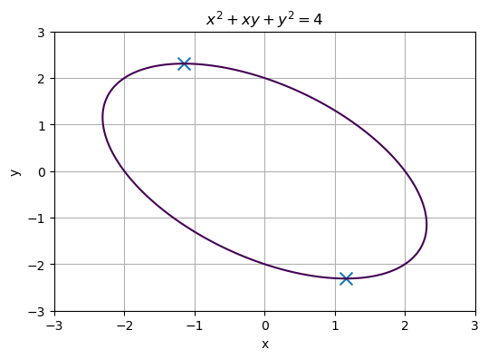

```python
fig = plt.figure(figsize=(6,4))
x = np.linspace(-3,3,101)
y = np.linspace(-3,3,101)
X,Y = np.meshgrid(x,y)
ax1 = fig.add_subplot(111)
ax1.contour(X,Y, X**2 + X*Y + Y**2, [4])
ax1.scatter([-np.sqrt(4/3), np.sqrt(4/3)], [2*np.sqrt(4/3), -2*np.sqrt(4/3)], s=100, marker='x')
ax1.set_xlabel('x')
ax1.set_ylabel('y')
ax1.set_title('$x^2 + xy + y^2 = 4$')
ax1.grid()
```

*b)*

Bestimmen die Steigungen folgender impliziter Funktionen:

- $(x^2+y^2)^2 - 2(x^2-y^2) = 0$

$$ f_x = 2(x^2+y^2)2x - 4x $$$$ f_y = 2(x^2+y^2)2y + 4y $$$$ f_{xx} = 12x^2+4y^2-4 $$

Die Ableitung von $y(x)$ ist: $$ y' =-\frac{f_x}{f_y} = -\frac{2(x^2+y^2)2x - 4x}{2(x^2+y^2)2y + 4y}$$ Die Ableitung ist null: $$ y'=0 \Leftrightarrow x^2+y^2=1$$ Punkte, in denen die Ableitung null ist, müssen die Gleichungen $x^2+y^2=1$ und gleichzeitig $(x^2+y^2)^2 - 2(x^2-y^2) = 0$ erfüllen: $$P_1= \left(\frac{\sqrt{3}}2,\frac12\right), P_2= \left(\frac{\sqrt{3}}2,-\frac12\right), P_3= \left(-\frac{\sqrt{3}}2,\frac12\right), P_4= \left(-\frac{\sqrt{3}}2,-\frac12\right) $$ Wenn $x^2+y^2=1$: $ f_{xx} = (8+4)x^2 + 4y^2-4 = 8x^2 + 4(x^2+y^2) - 4 = 8x^2$
Wenn $x^2+y^2=1$: $ f_y = 8y $
Für $P_2$ und $P_4$: $y'' = -\frac{f_{xx}}{f_y} = -\frac{8x^2}{8y}>0 \Rightarrow$ lokales Minimum
Für $P_1$ und $P_3$: $y'' = -\frac{f_{xx}}{f_y} = -\frac{8x^2}{8y}<0 \Rightarrow$ lokales Maximum.

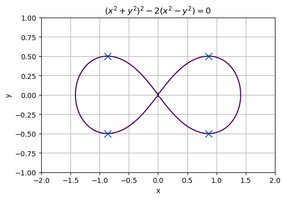

```python
fig = plt.figure(figsize=(6,4))
ry = np.sqrt(1/4)
rx = np.sqrt(3/4)
ax2 = fig.add_subplot(111)
x = np.linspace(-2,2,101)
y = np.linspace(-1,1,101)
X,Y = np.meshgrid(x,y)
ax2.contour(X,Y, (X**2 + Y**2)**2 - 2*(X**2- Y**2), [0])
ax2.scatter([rx,rx,-rx,-rx], [ry,-ry,ry,-ry], s=100, marker='x')
ax2.set_xlabel('x')
ax2.set_ylabel('y')
ax2.set_title('$(x^2 + y^2)^2 - 2(x^2 - y^2) = 0$')
ax2.grid()
```

*b)*

Bestimmen die Steigungen folgender impliziter Funktionen:

- $x^3 -3x^2 + 4y^2=4$

$$ f_x = 3x^2 -6x$$$$ f_y = 8y $$$$ f_{xx} = 6x-6 $$

Die Ableitung von $y(x)$ ist: $$ y' =-\frac{f_x}{f_y} = -\frac{3x^2-6x}{8y}$$ Die Ableitung ist null: $$ y'=0 \Leftrightarrow 3x^2-6x=0 \Rightarrow x\in\{0,2\}$$ Punkte, in denen die Ableitung null ist, müssen die Gleichungen $3x^2-6x=0$ und gleichzeitig $x^3 -3x^2 + 4y^2=4$ erfüllen: $$P_1= \left(0,1\right), P_2= \left(0,-1\right), P_3= \left(2,\sqrt{2}\right), P_4= \left(2,-\sqrt{2}\right) $$

Für $P_1$: $y'' = -\frac{f_{xx}}{f_y} = -\frac{6x-6}{8y} = -\frac{-6}{8}>0 \Rightarrow$ lokales Minimum  
Für $P_2$: $y'' = -\frac{f_{xx}}{f_y} = -\frac{6x-6}{8y} = -\frac{-6}{-8}<0 \Rightarrow$ lokales Maximum  
Für $P_3$: $y'' = -\frac{f_{xx}}{f_y} = -\frac{6x-6}{8y} = -\frac{6}{8\sqrt{2}}<0 \Rightarrow$ lokales Maximum  
Für $P_4$: $y'' = -\frac{f_{xx}}{f_y} = -\frac{6x-6}{8y} = -\frac{6}{-8\sqrt{2}}>0 \Rightarrow$ lokales Minimum

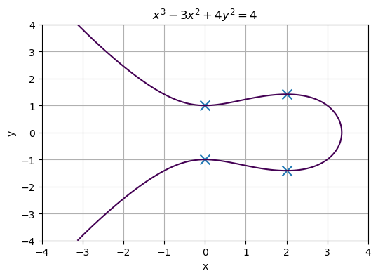

```python
fig = plt.figure(figsize=(6,4))
ax3 = fig.add_subplot(111)
x = np.linspace(-4,4,101)
y = np.linspace(-4,4,101)
X,Y = np.meshgrid(x,y)
ax3.contour(X,Y, X**3 - 3*X**2 + 4*Y**2, [4])
ax3.scatter([0,0,2,2], [1,-1,np.sqrt(2),-np.sqrt(2)], s=100, marker='x')
ax3.set_xlabel('x')
ax3.set_ylabel('y')
ax3.set_title('$x^3 - 3x^2 + 4y^2 = 4$')
ax3.grid()
```

### Anwendungen des Totalen Differential / Kettenregel

*c)*

Für den Radius $R$ und die Dichte $\varrho$ einer homogenen Kugel wurden die Mittelwerte $\bar{R} = 12.2 \mathrm{cm}$ und $\bar{\varrho} = 2.5 \mathrm{\frac{g}{cm^3}}$ ermittelt. Eine Schätzung der zugehörigen Messunsicherheiten ergab $\Delta R = 0.15 \mathrm{cm}$ und $\Delta \varrho = 0.11\mathrm{\frac{g}{cm^3}}$.

Welche Masse $m$ besitzt die Kugel? Gib dabei das Ergebnis in der Mittelwert $\pm$ Standardabweichung des Mittelwertes an.

#### Lösung

Masse: $$ m = V\rho = \frac43\pi R^3\rho$$ Für lineare Approximation: $$m = \overline{m}\pm\Delta m_{max}$$ $$\overline{m} = m(\overline{R},\overline{\rho})=\frac43\pi \overline{R}^3\overline{\rho}=19.016kg$$ $$\Delta m_{max} = \left| m_R\Delta R \right| + \left| m_{\rho}\Delta\rho \right| = \left| 4\pi\overline{R}^2\overline{\rho}\Delta R \right| + \left| \frac43\pi \overline{R}^3\Delta\rho \right|=1.538kg $$

### Anwendungen des Totalen Differential / Kettenregel

*d)*

Gegeben sei folgendes Skalarfeld: $$\varphi(x,y,z) = x^2 \mathrm{e}^{yz} + y z^3$$ Bestimmen Sie am Punkt $P = (2,0,1)$:

- den Gradienten des Skalarfeldes;
- und die Richtungsableitung entlang $\vec{\mathbf{v}}_1 = \left[\begin{array}{c} 1 \\2 \\3 \end{array}\right]$. $\vec{\mathbf{v}}_2 = \left[\begin{array}{c} 2 \\4 \\6 \end{array}\right]$ und $\vec{\mathbf{v}}_3 = \left[\begin{array}{c} 3 \\2 \\1 \end{array}\right]$

Finden Sie die Richtung mit der größten Ableitung, der kleinsten Ableitung und die Richtung, in der die Richtungsableitung null ist.

#### Lösung

Gradient: $$\nabla\varphi = \left[\begin{array}{c} \varphi_x \\ \varphi_y \\ \varphi_z \end{array}\right] = \left[\begin{array}{c} 2xe^{yz}+yz^3 \\ x^2ze^{yz}+z^3 \\ x^2ye^{yz}+3yz^2 \end{array}\right] $$ am Punkt $(2,0,1)$: $$\nabla\varphi(2,0,1) = \left[\begin{array}{c} 4 \\ 5 \\ 0\end{array}\right]$$

Die Richtungsableitung: $$ \frac{\partial\varphi}{\partial\vec{v}} = \frac{1}{\|\vec{v}\|}\nabla\varphi\cdot\vec{v} $$

$\vec{\mathbf{v}}_1 = \left[\begin{array}{c} 1 \\2 \\3 \end{array}\right] \rightarrow \|\vec{\mathbf{v}}_1\|=\sqrt{1^2+2^2+3^2}=\sqrt{14} \rightarrow \frac{\partial\varphi}{\partial\vec{v}_1}=\frac{1}{\sqrt{14}}14 = \sqrt{14} $  
$\vec{\mathbf{v}}_2 = \left[\begin{array}{c} 2 \\4 \\6 \end{array}\right] \rightarrow \|\vec{\mathbf{v}}_2\|=\sqrt{2^2+4^2+6^2}=2\sqrt{14} \rightarrow \frac{\partial\varphi}{\partial\vec{v}_2}=\frac{1}{2\sqrt{14}}28 = \sqrt{14} $  
$\vec{\mathbf{v}}_3 = \left[\begin{array}{c} 3 \\2 \\1 \end{array}\right] \rightarrow \|\vec{\mathbf{v}}_3\|=\sqrt{3^2+2^2+1^2}=\sqrt{14} \rightarrow \frac{\partial\varphi}{\partial\vec{v}_3}=\frac{1}{\sqrt{14}}22 $

Größte Richtungsableitung ($\alpha$ ist der Winkel zwischen dem Gradienten und dem Richtungsvektor $\vec{v}$): $$ \frac{\partial\varphi}{\partial\vec{v}} = \frac{1}{\|\vec{v}\|}\nabla\varphi\cdot\vec{v} = \frac{1}{\|\vec{v}\|} \|\nabla\varphi\|\|\vec{v}\|\cos(\alpha) = \|\nabla\varphi\|\cos(\alpha) $$

Der Wert ist am größten, wenn $\cos(\alpha) = 1 \Rightarrow \alpha = 0$, also in Richtung des Gradienten.  
Der Wert ist am kleinsten, wenn $\cos(\alpha) = -1 \Rightarrow \alpha = 180^\circ$, also in entgegengesetzter Richtung zum Gradienten.  
Die Richtungsableitung ist $0$, wenn $\cos(\alpha) = 0$, bzw. wenn $\nabla\varphi\cdot \vec{v}=0$. Wenn wir den Vektor als $\vec{v}=\left[\begin{array}{c} x\\y\\z\end{array}\right]$ bezeichnen, dann erhalten wir $4x+5y=0$, und es gibt unendlich viele Lösungen $\left[\begin{array}{c} t\\-\frac{4}{5}t\\u\end{array}\right]$, wobei $t$ und $u$ frei gewählt werden können.